# Wednesday, March 11th, 2026

### Multi-dimensional arrays

It is often very useful to represent higher-dimensional data as a `numpy` array. There are many ways to generate multi-dimensional arrays with `numpy`. For example, we can reshape a 1D array into a compatible 2D shape using the `.reshape` method. The `.reshape` method takes in a sequence of integers that define the shape of the output array. For example, calling `.reshape(2,5)` on an array of length `10` will create an array containing `2` rows and `5` columns.

```python
np.arange(10).reshape(2,5)
```

```
array([[0, 1, 2, 3, 4],
       [5, 6, 7, 8, 9]])
```

```python
np.arange(10).reshape(5,2)
```

```
array([[0, 1],
       [2, 3],
       [4, 5],
       [6, 7],
       [8, 9]])
```

```python
np.arange(10).reshape(3,5)
```

```
---------------------------------------------------------------------------
ValueError                                Traceback (most recent call last)
Cell In[7], line 1
----> 1 np.arange(10).reshape(3,5)

ValueError: cannot reshape array of size 10 into shape (3,5)
```

Just like with 1D arrays, we can perform arithmetic operations elementwise on 2D arrays.

```python
my_2d_array = np.arange(10).reshape(2,5)
print(my_2d_array)
```

[output not shown]

```python
5 * my_2d_array
```

[output not shown]

```python
my_2d_array ** 3 % 3 == my_2d_array % 3
```

[output not shown]

Each array has an attribute `.shape` that stores the shape (i.e. number of rows, columns, etc.) of the array.

```python
my_2d_array.shape
```

[output not shown]

```python
len(my_2d_array)
```

[output not shown]

We can also use `np.ones` or `np.zeros` to generate multi-dimensional arrays:

```python
np.ones(10)
```

```
array([1., 1., 1., 1., 1., 1., 1., 1., 1., 1.])
```

```python
10*np.ones((10,4))
```

```
array([[10., 10., 10., 10.],
       [10., 10., 10., 10.],
       [10., 10., 10., 10.],
       [10., 10., 10., 10.],
       [10., 10., 10., 10.],
       [10., 10., 10., 10.],
       [10., 10., 10., 10.],
       [10., 10., 10., 10.],
       [10., 10., 10., 10.],
       [10., 10., 10., 10.]])
```

```python
np.zeros((4,6), dtype=int)
```

```
array([[0, 0, 0, 0, 0, 0],
       [0, 0, 0, 0, 0, 0],
       [0, 0, 0, 0, 0, 0],
       [0, 0, 0, 0, 0, 0]])
```

```python
np.full((3,6), 4)
```

```
array([[4, 4, 4, 4, 4, 4],
       [4, 4, 4, 4, 4, 4],
       [4, 4, 4, 4, 4, 4]])
```

```python
list_of_lists = [[1,2,3], [4,5,6], [7,8,9], [10, 11, 12]]
print(list_of_lists)
```

```
[[1, 2, 3], [4, 5, 6], [7, 8, 9], [10, 11, 12]]
```

```python
my_2d_array = np.array(list_of_lists)
print(my_2d_array)
```

```
[[ 1  2  3]
 [ 4  5  6]
 [ 7  8  9]
 [10 11 12]]
```

With multi-dimensional arrays, we can slice across any axis of the array. This works just like regular list/array slicing, except that we can separately slice through a row, columm, or any other axis. We use commas inside the slice to separate between different dimensions of the array. For example, taking `[:,0]` will produce a slice consisting of elements from every row (the first dimension), but only the first column (e.g. the index-`0` entry of the second dimension, i.e. the columns).

```python
first_column = []
for row in list_of_lists:
    first_column.append(row[0])
print(first_column)
```

```
[1, 4, 7, 10]
```

```python
first_column = [ row[0] for row in list_of_lists ]
print(first_column)
```

```
[1, 4, 7, 10]
```

```python
print(my_2d_array[:,0])
```

```
[ 1  4  7 10]
```

```python
print(my_2d_array[:,1])
```

```
[ 2  5  8 11]
```

```python
print(my_2d_array[:,2])
```

```
[ 3  6  9 12]
```

```python
print(my_2d_array[1:,:-1])
```

```
[[ 4  5]
 [ 7  8]
 [10 11]]
```

As an example, consider a list of lists of Pythagorean triples $(a,b,c)$.

```python
ptriples = [[3, 4, 5],
[4, 3, 5],
[5, 12, 13],
[6, 8, 10],
[8, 6, 10],
[8, 15, 17],
[9, 12, 15],
[12, 5, 13],
[12, 9, 15],
[12, 16, 20],
[15, 8, 17],
[15, 20, 25],
[16, 12, 20],
[20, 15, 25]]
```

We've previously discussed how we may want to select just the $a$ and $b$ parts of each triple so that we can plot them against one another. This can be done using list comprehension or by initializing empty lists and building them up. What if we converted this list of lists into a `numpy` array?

```python
ptriples_arr = np.array(ptriples)
print(ptriples_arr)
```

```
[[ 3  4  5]
 [ 4  3  5]
 [ 5 12 13]
 [ 6  8 10]
 [ 8  6 10]
 [ 8 15 17]
 [ 9 12 15]
 [12  5 13]
 [12  9 15]
 [12 16 20]
 [15  8 17]
 [15 20 25]
 [16 12 20]
 [20 15 25]]
```

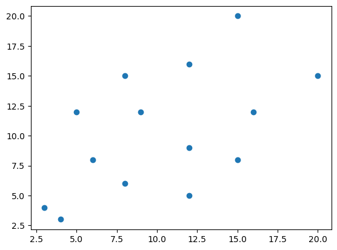

```python
a = ptriples_arr[:, 0]
b = ptriples_arr[:, 1]
c = ptriples_arr[:, 2]

plt.plot(a,b,'o')
```

## Visualizing 2-dimensional arrays

Consider the following 2D-array, filled with integers `0` up to `99`.

```python
A = np.arange(100).reshape(10,10)
print(A)
```

```
[[ 0  1  2  3  4  5  6  7  8  9]
 [10 11 12 13 14 15 16 17 18 19]
 [20 21 22 23 24 25 26 27 28 29]
 [30 31 32 33 34 35 36 37 38 39]
 [40 41 42 43 44 45 46 47 48 49]
 [50 51 52 53 54 55 56 57 58 59]
 [60 61 62 63 64 65 66 67 68 69]
 [70 71 72 73 74 75 76 77 78 79]
 [80 81 82 83 84 85 86 87 88 89]
 [90 91 92 93 94 95 96 97 98 99]]
```

For this array, it is small enough that we can simply print the array to understand its contents. For other larger arrays, this becomes infeasable. The `plt.imshow` function is a very useful tool for visualizing 2D arrays of any size. The basic syntax is `plt.imshow(<some 2D array>)`.

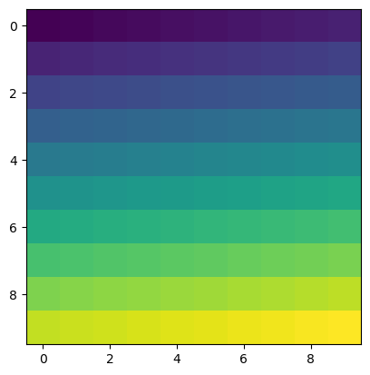

```python
plt.imshow(A)
```

When calling `plt.imshow` on a 2D array, the graph places a colored block at each row & column index pair. The color of the block is determined by the value of the array in that row & column position. The colors are assigned according to a designated *colormap*.

The colors are assigned so that the lowest value in the array is assigned the "lowest" color in the colormap (dark blue by default) and the highest value of the array is assigned the "highest" color in the colormap (yellow by default). Intermdiate values are assigned intermediate colors between the "lowest" and "highest" colors in the colormap.

Let's make some changes to the `A` array and see how the output of `plt.imshow` is affected. For example, suppose we want to set the values in rows `3` or `4` and columns `6` or `7` to be `120`.

```python
A[3:5, 6:8] = 120
print(A)
```

```
[[  0   1   2   3   4   5   6   7   8   9]
 [ 10  11  12  13  14  15  16  17  18  19]
 [ 20  21  22  23  24  25  26  27  28  29]
 [ 30  31  32  33  34  35 120 120  38  39]
 [ 40  41  42  43  44  45 120 120  48  49]
 [ 50  51  52  53  54  55  56  57  58  59]
 [ 60  61  62  63  64  65  66  67  68  69]
 [ 70  71  72  73  74  75  76  77  78  79]
 [ 80  81  82  83  84  85  86  87  88  89]
 [ 90  91  92  93  94  95  96  97  98  99]]
```

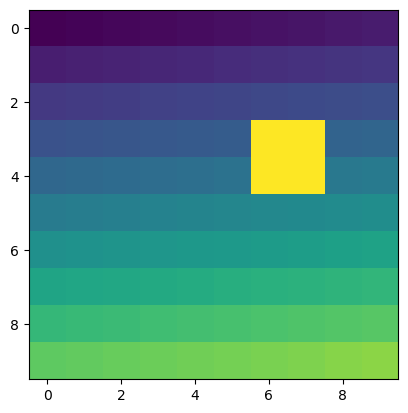

```python
plt.imshow(A)
```

Note: Just like the `plt.plot` function, we can take manual control of the figure and axes generation using `plt.figure` and `plt.subplot`. We can use `plt.imshow` within a subplot in the same way that we use `plt.plot`. There are also *many* optional arguments that can be included to modify the default behavior of `plt.imshow`. For example:

- We can supply a value `vmin` that the "darkest" color will be assigned to. Any values in the array that are below this minimum value will also be mapped to the "darkest" color.
- We can supply a value `vmax` that the "brightest" color will be assigned to. Any values in the array that are above this maximum value will also be mapped to the "brightest" color.

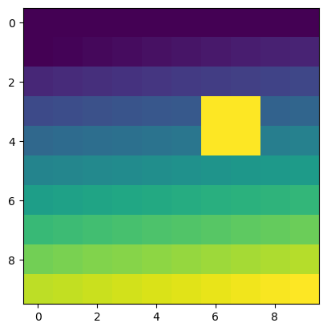

```python
plt.imshow(A, vmin=10, vmax=99)
```

By default, `plt.imshow` will not interpolate colors between neighboring array positions (unless your screen's resolution is too low to display all of the colored blocks). That is, we can see a discrete set of boxes of colors. We can modify this behavior by using the `interpolation` keyword. Some available interpolation methods include:

- `'nearest'`: each pixel is colored according to the closest colored block to that pixel
- `'bilinear'`: each pixel is colored according to a [bilinear interpolation](https://en.wikipedia.org/wiki/Bilinear_interpolation) (both horizontally and vertically) between nearby colored blocks
- `'bicubic'`: each pixel is colored according to a [bicubic interpolation](https://en.wikipedia.org/wiki/Bicubic_interpolation) (both horizontally and vertically) between nearby colored blocks
- `'lanczos'`: each pixel is colored according to [Lancsoz interpolation](https://en.wikipedia.org/wiki/Lanczos_resampling) (both horizontally and vertically) between nearby colored blocks

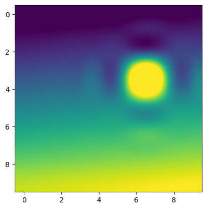

```python
plt.imshow(A, vmin=10, vmax=99, interpolation='lanczos')
```

We can also modify the color choices used by `plt.imshow`. These choices are called *colormaps*. A collection of colormaps can be found on the [Matplotlib documentation page](https://matplotlib.org/stable/users/explain/colors/colormaps.html).

The `cmap` keyword argument can be used to change colormaps:

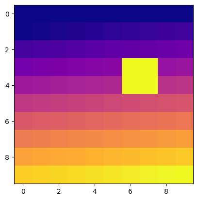

```python
plt.imshow(A, vmin=10, vmax=99, cmap='plasma')
```

Note: The figures produced above do not indicate what the actual values in the array are. We can call `plt.colorbar` to add a colorbar that indicates which values correspond to which colors.

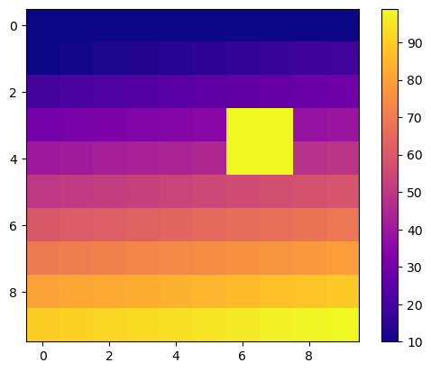

```python
plt.imshow(A, vmin=10, vmax=99, cmap='plasma')
plt.colorbar()
```

We can also use colormaps in `plt.plot` to assign colors to our plots. The colormaps can be found in the `cm` submodule of `matplotlib`.

```python
import matplotlib.cm as cm
```

**plasma**

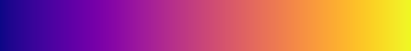

```python
cm.plasma
```

Each colormap works as a function that takes in a float, where:

- any input `0` or less returns the color at the left-end of the colormap,
- any input `1` or more returns the color at the right-end of the colormap,
- any input between `0` and `1` returns the color that is proportionally between the left-end and right-end of the colormap.

```python
cm.plasma(.1)
```

```
(np.float64(0.254627),
 np.float64(0.013882),
 np.float64(0.615419),
 np.float64(1.0))
```

```python
cm.plasma(.5)
```

```
(np.float64(0.798216),
 np.float64(0.280197),
 np.float64(0.469538),
 np.float64(1.0))
```

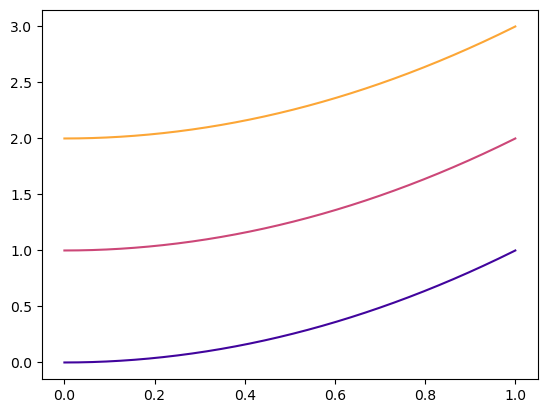

```python
t = np.linspace(0,1,1000)

plt.plot(t, t**2, color = cm.plasma(.1))
plt.plot(t, t**2 + 1, color = cm.plasma(.5))
plt.plot(t, t**2 + 2, color = cm.plasma(.8))
```

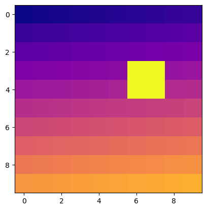

```python
plt.imshow(A, cmap = cm.plasma)
```

What does the output actually look like when we plug a float into a colormap?

```python
print(cm.plasma(.3))
```

```
(np.float64(0.562738), np.float64(0.051545), np.float64(0.641509), np.float64(1.0))
```

## RGB(A) values

The output from the colormap above is an Red/Green/Blue/Alpha value, or *RGBA* value. That is, we have a tuple `(R, G, B, A)` where:

- `R` is the amount of red in the color (`R=1` means full red, `R=0` means no red),
- `G` is the amount of green in the color (`G=1` means full green, `G=0` means no green),
- `B` is the amount of blue in the color (`B=1` means full blue, `B=0` means no blue),
- `A` is the transparency of the color (`A=1` means fully opaque, `A=0` means fully transparent).

If the transparency channel is omitted (i.e. if we work with a pure RGB triple), the color is assume to be fully opaque. We can also supply our own RGB(A) tuples in `plt.plot` to specify colors.

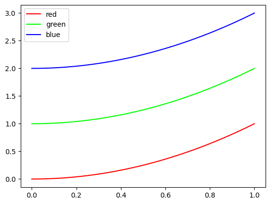

```python
t = np.linspace(0,1,1000)

plt.plot(t, t**2, color = (1,0,0), label='red')
plt.plot(t, t**2 + 1, color = (0,1,0), label='green')
plt.plot(t, t**2 + 2, color = (0,0,1), label='blue')

plt.legend()
```

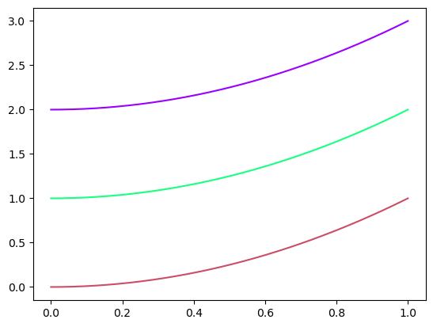

```python
t = np.linspace(0,1,1000)

plt.plot(t, t**2, color = (.8,.3,.4))
plt.plot(t, t**2 + 1, color = (.1,1,.5))
plt.plot(t, t**2 + 2, color = (.6,0,1))
```

The `plt.imshow` function can also work with RGB(A) values. Instead of supplying a 2D-array, we can supply a 3D-array where:

- The first axis corresponds to the row of the array,
- The second axis corresponds to the column of the array,
- The third axis corresponds to the RGB(A) values of the array.

For example, let's define a `10` by `20` array with `3` color channels (RGB) called `RGB_array`.

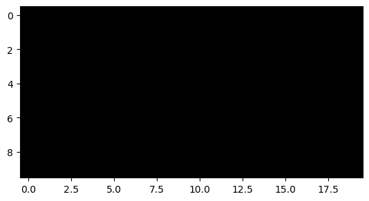

```python
RGB_array = np.zeros((10,20,3))

plt.imshow(RGB_array)
```

```python
RGB_array[:,:].shape
```

```
(10, 20, 3)
```

For the above array, we will think of `RGB_array[:,:,0]` as a $2D$-array containing the red data. Similarly, `RGB_array[:,:,1]` contains the green data, and `RGB_array[:,:,2]` contains the blue data. Let's add some colored stripes to the array.

*Note:* We can take slices through the rows/columns of an `(m,n,3)` array of RGB values. For example, `RGB_array[:4, 3:7]` will give a `(4,4,3)` array consisting of the RGB triples in rows `0`, `1`, `2`, `3` and columns `3`, `4`, `5`, `6`. If we set `RGB_array[:4, 3:7] = (.1, .7, .9)`, then every RGB triple in these rows/columns will be set to `(.1, .7, .9)`. This is called *broadcasting*, and is a very useful feature of NumPy.

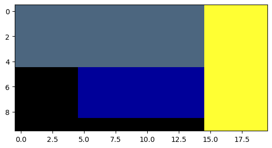

```python
RGB_array[:5] = (.3, .4, .5)

RGB_array[:, 15:] = (1, 1, .2)

RGB_array[5:9, 5:15] = (0, 0, .6)

plt.imshow(RGB_array)
```

Most computer images are stored as arrays of RGB(A) values. We can read an image file into an RGB(A) array using `plt.imread`. The syntax is: `plt.imread(<path to some image file>)`. For example, download the image `mario.png` from the [course webpage](https://jllottes.github.io/Schedule/week_08.html) and place it into the same folder as this Jupyter notebook.

```
(224, 256, 4)
```

[figure not shown]

```python
mario = plt.imread('mario.png')
print(mario.shape)

plt.imshow(mario)
```

We can look at the shape of the array to see if it contains RGB or RGBA values. In this case, the `mario.png` image file includes a transparency channel.

```python
print(mario.shape)
```

```
(224, 256, 4)
```

**Exercise:** Use NumPy slicing to remove the transparency channel from the `mario` array.**

```python
mario = mario[:, :, :3]
```

[figure not shown]

```python
plt.imshow(mario)
```

**Exercise:** Use NumPy slicing and `plt.imshow` to zoom in on Mario (in the lower-left corner).

**Exercise:** Create an array `blueless_mario` where the blue channel information from `mario` has been removed (i.e. set to `0`) and plot using `plt.imshow`.

```python
blueless_mario = mario.copy()
```

**Exercise:** Create an array `mixed_mario` where:

- the red channel of `mixed_mario` matches the green channel of `mario`,
- the green channel of `mixed_mario` matches the blue channel of `mario`,
- the blue channel of `mixed_mario` matches the red channel of `mario`.

*Note:* For the next project, we will be working with integer-valued RGB triples. The integer-values will range from `0` to `255`. An integer `0` means no color while an integer `255` means full color (equivalent to a float of `1`).

**Exercise:** Convert the `mario` array to an integer-type array `mario_RGB_int` containing RGB triples with values between `0` and `255`.

**Exercise**: Convert the `mario_RGB_int` array into a float-type array containing RGB triples with values between `0` and `1`.